# Лабораторная работа №3

Управляющие структуры

Александр Эдуардович Аскеров

Российский университет дружбы народов

2025-10-11

# Информация

## Докладчик

- Аскеров Александр Эдуардович
- Кафедра теории вероятностей и кибербезопасности
- Российский университет дружбы народов им. П. Лумумбы

# Вводная часть

## Цель работы

Основная цель работы – освоить применение циклов, функций и сторонних для Julia пакетов для решения задач линейной алгебры и работы с матрицами.

## Задание

1. Используя Jupyter Lab, повторите примеры из раздела 3.2.
2. Выполните задания для самостоятельной работы (раздел 3.4).

# Циклы

Выполним примеры из раздела циклы while и for.

Для различных операций, связанных с перебором индексируемых элементов структур данных, традиционно используются циклы while и for.

Например, while можно использовать для формирования элементов массива:

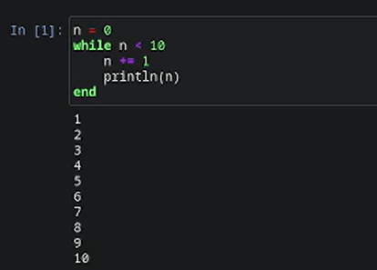

Рисунок 1: Циклы 1

# Циклы

Другой пример демонстрирует использование while при работе со строковыми элементами массива, подставляя имя из массива в заданную строку приветствия и выводя получившуюся конструкцию на экран:

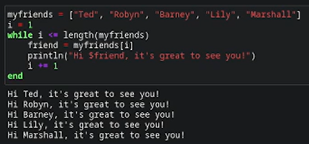

Рисунок 2: Циклы 2

# Циклы

Рассмотренные выше примеры, но с использованием цикла for:

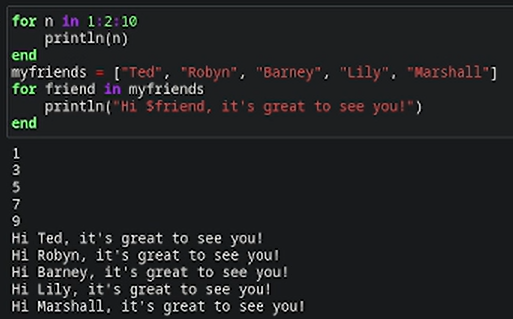

Рисунок 3: Циклы 3

# Циклы

Пример использования цикла for для создания двумерного массива, в котором значение каждой записи является суммой индексов строки и столбца:

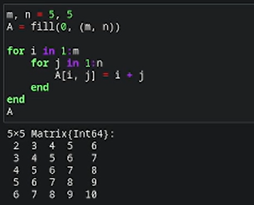

Рисунок 4: Циклы 4

# Циклы

Другая реализация этого же примера:

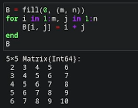

Рисунок 5: Циклы 5

# Циклы

Ещё одна реализация этого же примера:

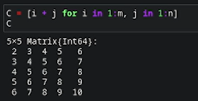

Рисунок 6: Циклы 6

# Условные выражения

Выполним примеры из раздела условные выражения.

Довольно часто при решении задач требуется проверить выполнение тех или иных условий. Для этого используют условные выражения.

Например, пусть для заданного числа $N$ требуется вывести слово «Fizz», если $N$ делится на 3, «Buzz», если $N$ делится на 5, и «FizzBuzz», если $N$ делится на 3 и 5:

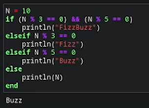

Рисунок 7: Условные выражения 1

# Условные выражения

# Функции

Выполним примеры из раздела функции.

Julia дает нам несколько разных способов написать функцию. Первый требует ключевых слов function и end:

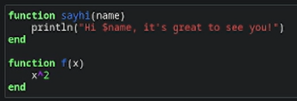

Рисунок 9: Функции 1

# Функции

Вызов функции осуществляется по её имени с указанием аргументов, например:

[figure not shown]

Рисунок 10: Функции 2

# Функции

В качестве альтернативы, можно объявить любую из выше определённых функций в одной строке:

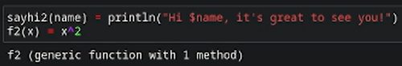

Рисунок 11: Функции 3

# Функции

Наконец, можно объявить выше определённые функции как «анонимные»:

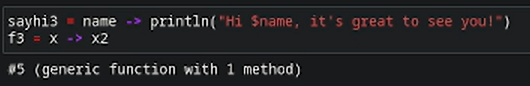

Рисунок 12: Функции 4

# Функции

По соглашению в Julia функции, сопровождаемые восклицательным знаком, изменяют свое содержимое, а функции без восклицательного знака не делают этого.

Например, сравните результат применения sort и sort!:

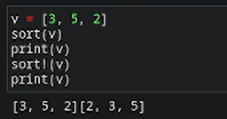

Рисунок 13: Функции 5

# Функции

Функция sort(v) возвращает отсортированный массив, который содержит те же элементы, что и массив v, но исходный массив v остаётся без изменений. Если же использовать sort!(v), то отсортировано будет содержимое исходного массива v.

В программировании под функцией высшего порядка понимается функция, принимающая в качестве аргументов другие функции или возвращающая другую функцию в качестве результата. Основная идея состоит в том, что функции имеют тот же статус, что и другие объекты данных.

# Функции

В Julia функция map является функцией высшего порядка, которая принимает функцию в качестве одного из своих входных аргументов и применяет эту функцию к каждому элементу структуры данных, которая ей передаётся также в качестве аргумента.

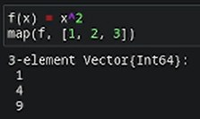

Рисунок 14: Функции 6

То есть в квадрат возведены все элементы массива [1, 2, 3], но не сам массив (вектор).

# Функции

# Функции

Функция broadcast – ещё одна функция высшего порядка в Julia, представляющая собой обобщение функции map. Функция broadcast() будет пытаться привести все объекты к общему измерению, map() будет напрямую применять данную функцию поэлементно.

Синтаксис для вызова broadcast такой же, как и для вызова map, например применение функции f к элементам массива [1, 2, 3]:

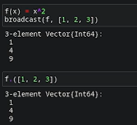

Рисунок 16: Функции 8

# Функции

Пример:

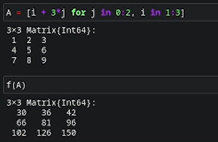

Рисунок 17: Функции 9

# Функции

# Функции

Точечный синтаксис для broadcast() позволяет записать относительно сложные составные поэлементные выражения в форме, близкой к математической записи.

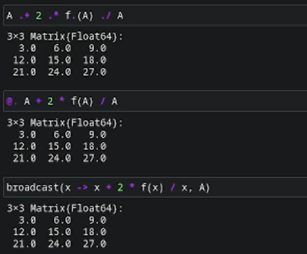

Рисунок 19: Функции 11

# Пакеты

Выполним примеры из раздела сторонние библиотеки (пакеты) в Julia.

При первом использовании пакета в вашей текущей установке Julia вам необходимо использовать менеджер пакетов, чтобы явно его добавить.

При каждом новом использовании Julia (например, в начале нового сеанса в REPL или открытии блокнота в первый раз) нужно загрузить пакет, используя ключевое слово using.

# Пакеты

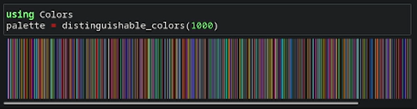

Рисунок 21: Пакеты 2

# Пакеты

А затем определим матрицу $3 \times 3$ с элементами в форме случайного цвета из палитры, используя функцию rand:

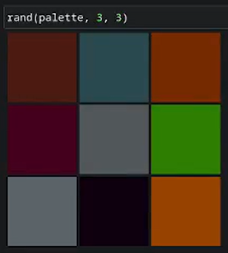

Рисунок 22: Пакеты 3

# Задания для самостоятельной работы

1. Используя циклы while и for:

1.1. Выведите на экран целые числа от 1 до 100 и напечатайте их квадраты.

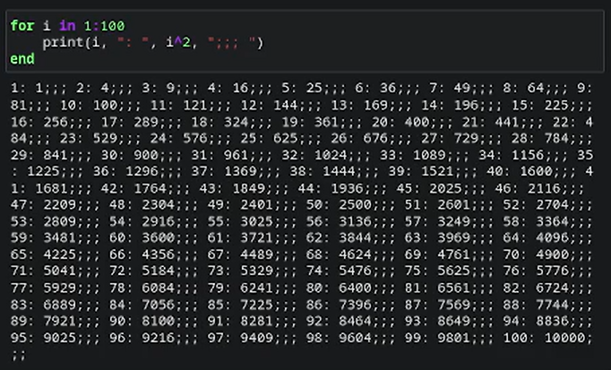

Рисунок 23: Задание 1.1

# Задания для самостоятельной работы

1.2. Создайте словарь squares, который будет содержать целые числа в качестве ключей и квадраты в качестве их пар-значений.

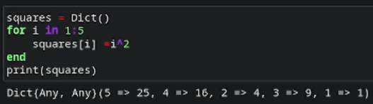

Рисунок 24: Задание 1.2

# Задания для самостоятельной работы

1.3. Создайте массив squares_arr, содержащий квадраты всех чисел от 1 до 100.

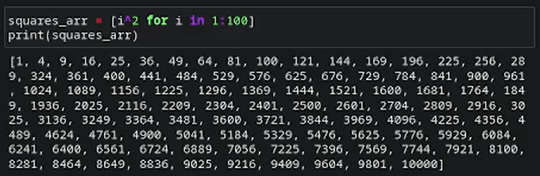

Рисунок 25: Задание 1.3

# Задания для самостоятельной работы

2. Напишите условный оператор, который печатает число, если число чётное, и строку «нечётное», если число нечётное. Перепишите код, используя тернарный оператор.

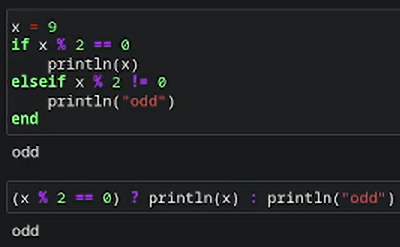

Рисунок 26: Задание 2

# Задания для самостоятельной работы

3. Напишите функцию add_one, которая добавляет 1 к своему входу.

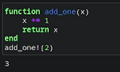

Рисунок 27: Задание 3

# Задания для самостоятельной работы

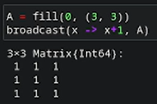

Рисунок 28: Задание 4

# Задания для самостоятельной работы

5. Задайте матрицу $A$:

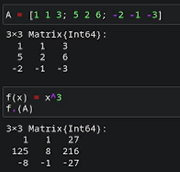

Рисунок 29: Задание 5.1

# Задания для самостоятельной работы

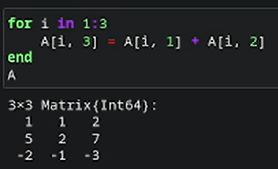

Рисунок 30: Задание 5.2

# Задания для самостоятельной работы

6. Создание матрицы $B$. Вычисление матрицы $C$.

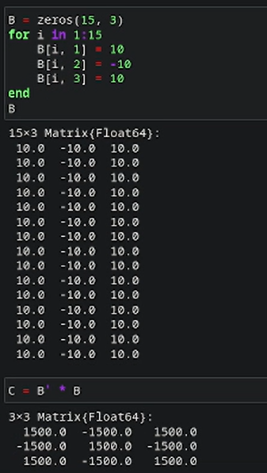

Рисунок 31: Задание 6

# Задания для самостоятельной работы

7. Создание матриц $Z_1$, $Z_2$, $Z_3$, $Z_4$.

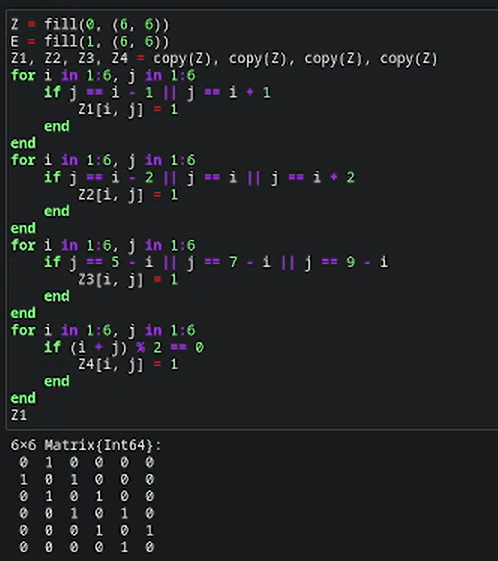

Рисунок 32: Задание 7